# Pertemuan 1 MPDW - Tugas

Andhias Abdillah Ridho

2026-08-21

# Packaage

```r
library("forecast")
```

```r
library("graphics")
library("TTR")
library("TSA")
```

# Data

```r
library(readxl)
data <- read_excel("C:\\Users\\LENOVO\\Downloads\\data tugas 1 mpdw.xlsx")
head(data)
```

```
## # A tibble: 6 × 2
##   observation_date    CPIAUCSL_PC1
##   <dttm>              <chr>
## 1 2008-01-01 00:00:00 429470
## 2 2008-02-01 00:00:00 414296
## 3 2008-03-01 00:00:00 397490
## 4 2008-04-01 00:00:00 390376
## 5 2008-05-01 00:00:00 408841
## 6 2008-06-01 00:00:00 493597
```

# Normalisasikan

```r
str(data)
```

```
## tibble [180 × 2] (S3: tbl_df/tbl/data.frame)
##  $ observation_date: POSIXct[1:180], format: "2008-01-01" "2008-02-01" ...
##  $ CPIAUCSL_PC1    : chr [1:180] "429470" "414296" "397490" "390376" ...
```

```r
data$CPIAUCSL_PC1 <- as.numeric(
  gsub(",", "", data$CPIAUCSL_PC1)
)
str(data)
```

```
## tibble [180 × 2] (S3: tbl_df/tbl/data.frame)
##  $ observation_date: POSIXct[1:180], format: "2008-01-01" "2008-02-01" ...
##  $ CPIAUCSL_PC1    : num [1:180] 429470 414296 397490 390376 408841 ...
```

# Mengubah data agar terbaca sebagai data deret waktu dengan fungsi ts()

```r
data.ts <- ts(data$CPIAUCSL_PC1 )
data.ts
```

```
## Time Series:
## Start = 1
## End = 180
## Frequency = 1
##   [1]  4.29470e+05  4.14296e+05  3.97490e+05  3.90376e+05  4.08841e+05
##   [6]  4.93597e+05  5.49751e+05  5.30802e+05  4.95332e+05  3.73106e+05
##  [11]  1.09992e+05 -2.22300e-02 -1.13590e-01  8.46000e-03 -4.46480e-01
##  [16] -5.76320e-01 -1.01576e+05 -1.22917e+05 -1.95876e+05 -1.48384e+05
##  [21] -1.37794e+05 -2.23970e-01  1.91459e+05  2.81412e+05  2.62111e+05
##  [26]  2.15134e+05  2.28617e+05  2.20677e+05  2.00355e+05  1.12156e+05
##  [31]  1.34078e+05  1.15018e+05  1.11831e+05  1.16670e+05  1.08454e+05
##  [36]  1.43779e+05  1.70078e+05  2.12490e+05  2.61924e+05  3.07723e+05
##  [41]  3.45897e+05  3.50232e+05  3.57988e+05  3.75500e+05  3.81262e+05
##  [46]  3.52227e+05  3.45143e+05  3.06207e+05  3.00877e+05  2.89818e+05
##  [51]  2.58288e+05  2.27316e+05  1.73794e+05  1.65387e+05  1.41751e+05
```

[output cut: 25 more lines]

```r
summary(data.ts)
```

```
##    Min. 1st Qu.  Median    Mean 3rd Qu.    Max.
## -195876  117497  186977  230829  280825  897936
```

# Plot data deret waktu

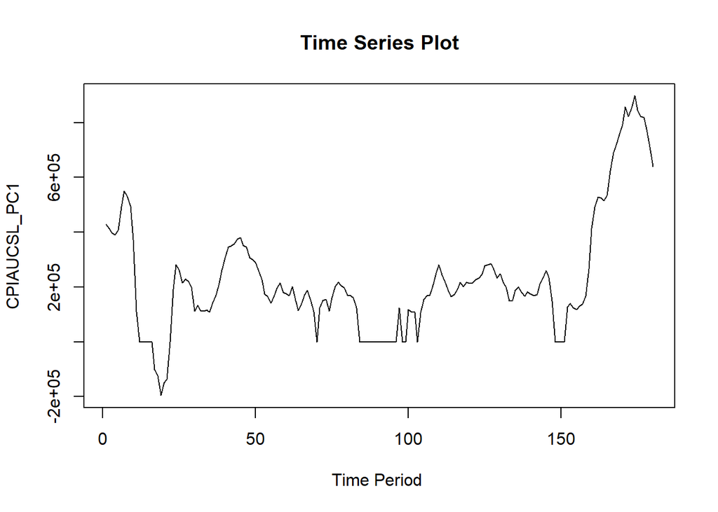

```r
ts.plot(data.ts, xlab="Time Period ", ylab="CPIAUCSL_PC1",
        main = "Time Series Plot")
```

# Single Moving Average & Double Moving Average

## Pembagian Data

Pembagian data latih dan data uji dilakukan dengan perbandingan 80% data latih dan 20% data uji.

```r
# hitung jumlah data
n <- nrow(data)

# tentukan batas 80%
n_train <- floor(0.8 * n)

# bagi data
training_ma <- data[1:n_train, ]
testing_ma  <- data[(n_train+1):n, ]

# ubah ke time series
train_ma.ts <- ts(training_ma$`CPIAUCSL_PC1`)
test_ma.ts  <- ts(testing_ma$`CPIAUCSL_PC1`)
```

```r
# cek jumlah data
cat("Jumlah data training :", nrow(training_ma), "\n")
```

```
## Jumlah data training : 144
```

```r
cat("Jumlah data testing  :", nrow(testing_ma), "\n")
```

```
## Jumlah data testing  : 36
```

```r
cat("Total data           :", nrow(training_ma) + nrow(testing_ma), "\n")
```

```
## Total data           : 180
```

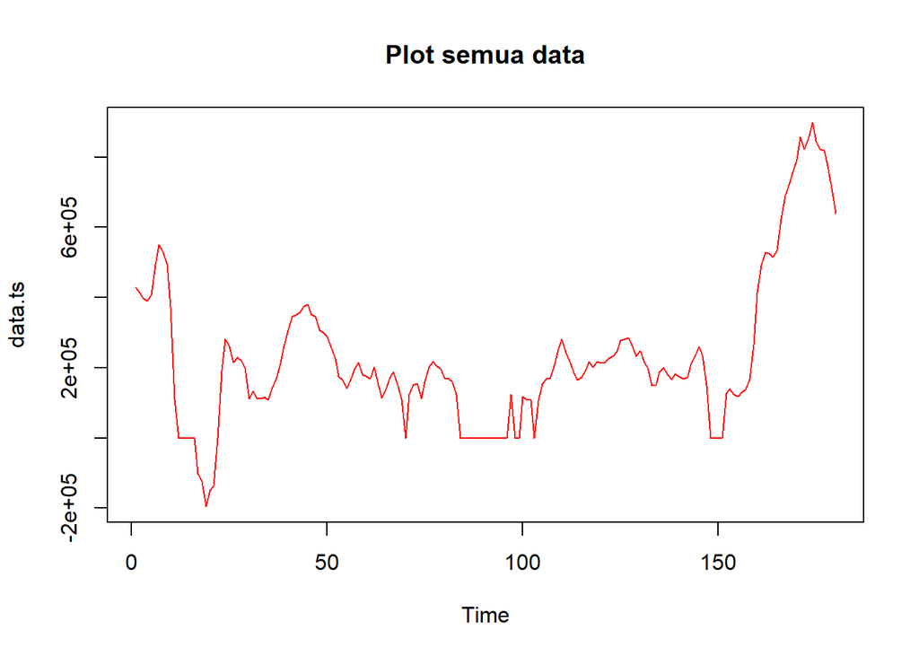

```r
#eksplorasi keseluruhan data
plot(data.ts, col="red",main="Plot semua data")
```

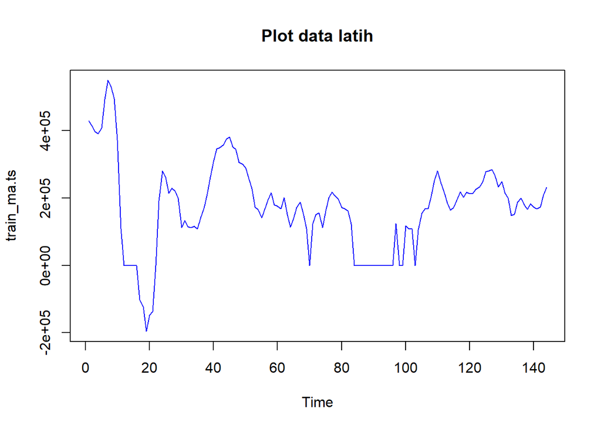

```r
#eksplorasi data latih
plot(train_ma.ts, col="blue",main="Plot data latih")
```

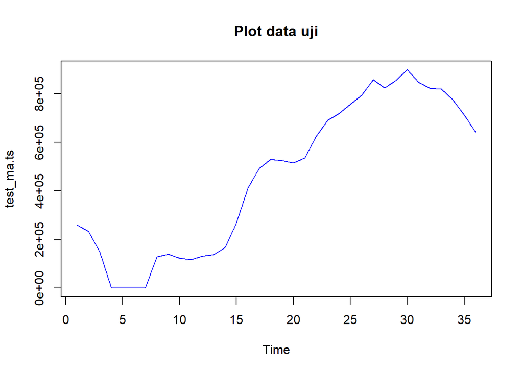

```r
#eksplorasi data uji
plot(test_ma.ts, col="blue",main="Plot data uji")
```

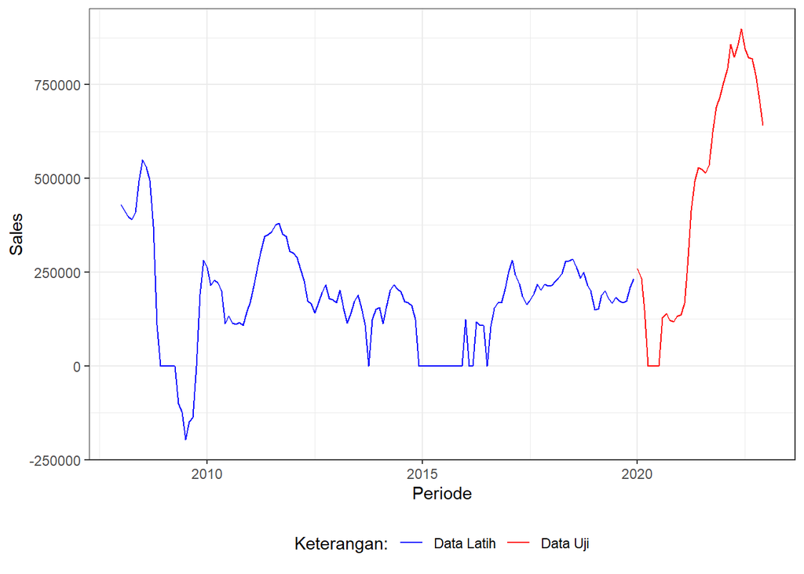

```r
library(ggplot2)

ggplot() +
  geom_line(
    data = training_ma,
    aes(x = observation_date, y = CPIAUCSL_PC1, col = "Data Latih")
  ) +
  geom_line(
    data = testing_ma,
    aes(x = observation_date, y = CPIAUCSL_PC1, col = "Data Uji")
  ) +
  labs(x = "Periode", y = "Sales", col = "Keterangan") +
  scale_colour_manual(
    name = "Keterangan:",
    breaks = c("Data Latih", "Data Uji"),
    values = c("blue", "red")
  ) +
  theme_bw() +
  theme(legend.position = "bottom")
```

## Single Moving Average (SMA)

```r
data.sma<-SMA(train_ma.ts, n=4)
data.sma
```

```
## Time Series:
## Start = 1
## End = 144
## Frequency = 1
##   [1]            NA            NA            NA  4.079080e+05  4.027507e+05
##   [6]  4.225760e+05  4.606413e+05  4.957478e+05  5.173705e+05  4.872477e+05
##  [11]  3.773080e+05  2.446075e+05  1.207745e+05  2.749797e+04 -1.434600e-01
##  [16] -2.819825e-01 -2.539425e+04 -5.612351e+04 -1.050924e+05 -1.421883e+05
##  [21] -1.512427e+05 -1.205136e+05 -2.367981e+04  8.376919e+04  1.837454e+05
##  [26]  2.375290e+05  2.468185e+05  2.316348e+05  2.161957e+05  1.904513e+05
##  [31]  1.668165e+05  1.404017e+05  1.182708e+05  1.193993e+05  1.129933e+05
##  [36]  1.201835e+05  1.347452e+05  1.587002e+05  1.970677e+05  2.380537e+05
##  [41]  2.820085e+05  3.164440e+05  3.404600e+05  3.574043e+05  3.662455e+05
##  [46]  3.667442e+05  3.635330e+05  3.462098e+05  3.261135e+05  3.105112e+05
##  [51]  2.887975e+05  2.690747e+05  2.373040e+05  2.061962e+05  1.770620e+05
```

[output cut: 18 more lines]

Data pemulusan pada periode ke-t selanjutnya digunakan sebagai nilai peramalan pada periode ke t+1 sehingga hasil peramalan 1 periode kedepan adalah sebagai berikut.

```r
data.ramal<-c(NA,data.sma)
data.ramal #forecast 1 periode ke depan
```

```
##   [1]            NA            NA            NA            NA  4.079080e+05
##   [6]  4.027507e+05  4.225760e+05  4.606413e+05  4.957478e+05  5.173705e+05
##  [11]  4.872477e+05  3.773080e+05  2.446075e+05  1.207745e+05  2.749797e+04
##  [16] -1.434600e-01 -2.819825e-01 -2.539425e+04 -5.612351e+04 -1.050924e+05
##  [21] -1.421883e+05 -1.512427e+05 -1.205136e+05 -2.367981e+04  8.376919e+04
##  [26]  1.837454e+05  2.375290e+05  2.468185e+05  2.316348e+05  2.161957e+05
##  [31]  1.904513e+05  1.668165e+05  1.404017e+05  1.182708e+05  1.193993e+05
##  [36]  1.129933e+05  1.201835e+05  1.347452e+05  1.587002e+05  1.970677e+05
##  [41]  2.380537e+05  2.820085e+05  3.164440e+05  3.404600e+05  3.574043e+05
##  [46]  3.662455e+05  3.667442e+05  3.635330e+05  3.462098e+05  3.261135e+05
##  [51]  3.105112e+05  2.887975e+05  2.690747e+05  2.373040e+05  2.061962e+05
##  [56]  1.770620e+05  1.623813e+05  1.676758e+05  1.802210e+05  1.896838e+05
##  [61]  1.915230e+05  1.848815e+05  1.814430e+05  1.745112e+05  1.589940e+05
##  [66]  1.516522e+05  1.440935e+05  1.532615e+05  1.632615e+05  1.558700e+05
##  [71]  1.129755e+05  9.666047e+04  9.601122e+04  1.075870e+05  1.355985e+05
##  [76]  1.450940e+05  1.576512e+05  1.728810e+05  1.963437e+05  2.053825e+05
##  [81]  1.978817e+05  1.858093e+05  1.745732e+05  1.560052e+05  1.131279e+05
##  [86]  7.102661e+04  3.078808e+04  7.853250e-02 -1.107550e-01 -4.451500e-02
##  [91]  2.213500e-02  8.406500e-02  1.703975e-01  1.638500e-01  1.508625e-01
##  [96]  2.035200e-01  3.028750e-01  3.093780e+04  3.093798e+04  3.093809e+04
## [101]  6.025368e+04  5.627818e+04  8.326022e+04  8.326022e+04  8.032747e+04
## [106]  9.208147e+04  1.072472e+05  1.493553e+05  1.742423e+05  1.982860e+05
## [111]  2.263970e+05  2.453188e+05  2.484543e+05  2.321030e+05  2.028583e+05
## [116]  1.849560e+05  1.787535e+05  1.868593e+05  1.963640e+05  2.075485e+05
## [121]  2.125938e+05  2.118625e+05  2.179303e+05  2.218918e+05  2.304185e+05
## [126]  2.461835e+05  2.597855e+05  2.728648e+05  2.771628e+05  2.659163e+05
## [131]  2.580283e+05  2.403585e+05  2.243450e+05  2.032333e+05  1.789040e+05
## [136]  1.723005e+05  1.722555e+05  1.799635e+05  1.837718e+05  1.823503e+05
## [141]  1.757768e+05  1.729915e+05  1.745610e+05  1.812100e+05  1.957573e+05
```

```r
data.gab<-cbind(
  aktual=c(data.ts),
  pemulusan=c(data.sma,rep(NA,100)),
  ramalan=c(data.ramal,rep(data.ramal[length(data.ramal)],99)))
data.gab
```

```
##              aktual     pemulusan       ramalan
##   [1,]  4.29470e+05            NA            NA
##   [2,]  4.14296e+05            NA            NA
##   [3,]  3.97490e+05            NA            NA
##   [4,]  3.90376e+05  4.079080e+05            NA
##   [5,]  4.08841e+05  4.027507e+05  4.079080e+05
##   [6,]  4.93597e+05  4.225760e+05  4.027507e+05
##   [7,]  5.49751e+05  4.606413e+05  4.225760e+05
##   [8,]  5.30802e+05  4.957478e+05  4.606413e+05
##   [9,]  4.95332e+05  5.173705e+05  4.957478e+05
##  [10,]  3.73106e+05  4.872477e+05  5.173705e+05
##  [11,]  1.09992e+05  3.773080e+05  4.872477e+05
##  [12,] -2.22300e-02  2.446075e+05  3.773080e+05
##  [13,] -1.13590e-01  1.207745e+05  2.446075e+05
##  [14,]  8.46000e-03  2.749797e+04  1.207745e+05
```

[output cut: 230 more lines]

Adapun plot data deret waktu dari hasil peramalan yang dilakukan adalah sebagai berikut:

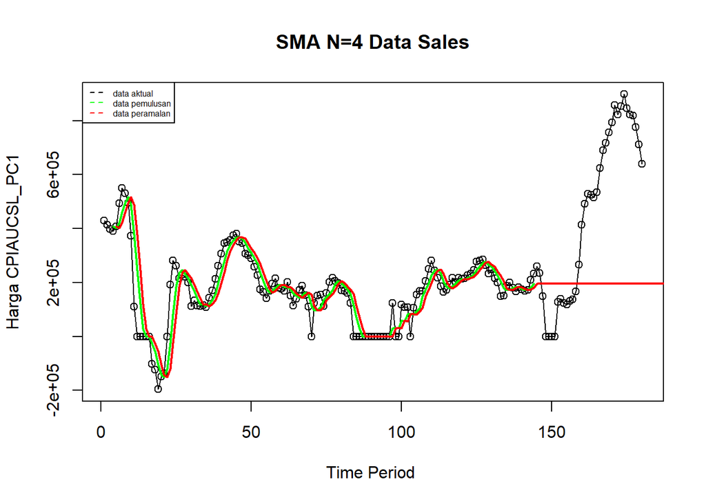

```r
ts.plot(data.ts, xlab="Time Period ", ylab="Harga CPIAUCSL_PC1", main= "SMA N=4 Data Sales")
points(data.ts)
lines(data.gab[,2],col="green",lwd=2)
lines(data.gab[,3],col="red",lwd=2)
legend("topleft",c("data aktual","data pemulusan","data peramalan"), lty=8, col=c("black","green","red"), cex=0.5)
```

```r
#Menghitung nilai keakuratan data latih
error_train.sma = train_ma.ts-data.ramal[1:length(train_ma.ts)]

SSE_train.sma = sum(error_train.sma[5:length(train_ma.ts)]^2)
MSE_train.sma = mean(error_train.sma[5:length(train_ma.ts)]^2)
MAPE_train.sma = mean(abs((error_train.sma[5:length(train_ma.ts)]/train_ma.ts[5:length(train_ma.ts)])*100))

akurasi_train.sma <- matrix(c(SSE_train.sma, MSE_train.sma, MAPE_train.sma))
row.names(akurasi_train.sma)<- c("SSE", "MSE", "MAPE")
colnames(akurasi_train.sma) <- c("Akurasi m = 4")
akurasi_train.sma
```

```
##      Akurasi m = 4
## SSE   1.008835e+12
## MSE   7.205967e+09
## MAPE  2.673473e+07
```

```r
#Menghitung nilai keakuratan data uji
error_test.sma = test_ma.ts-data.gab[97:120,3]
```

```r
SSE_test.sma = sum(error_test.sma^2)
MSE_test.sma = mean(error_test.sma^2)
MAPE_test.sma = mean(abs((error_test.sma/test_ma.ts*100)))

akurasi_test.sma <- matrix(c(SSE_test.sma, MSE_test.sma, MAPE_test.sma))
row.names(akurasi_test.sma)<- c("SSE", "MSE", "MAPE")
colnames(akurasi_test.sma) <- c("Akurasi m = 4")
akurasi_test.sma
```

```
##      Akurasi m = 4
## SSE   7.909154e+12
## MSE   2.196987e+11
## MAPE  1.569168e+06
```

Nilai SSE dan MSE data uji jauh lebih besar dibandingkan data latih. Hal ini menunjukkan bahwa model memiliki kesalahan prediksi yang lebih besar ketika diterapkan pada data yang belum pernah dilihat sebelumnya. Dengan demikian, kemampuan generalisasi model masih kurang baik dan terdapat indikasi model kurang mampu memprediksi data uji secara akurat.

# Double Moving Average (DMA)

```r
dma <- SMA(data.sma, n = 4)
At <- 2*data.sma - dma
Bt <- 2/(4-1)*(data.sma - dma)
data.dma<- At+Bt
data.ramal2<- c(NA, data.dma)

t = 1:24
f = c()

for (i in t) {
  f[i] = At[length(At)] + Bt[length(Bt)]*(i)
}

data.gab2 <- cbind(aktual = c(data.ts),
                   pemulusan1 = c(data.sma,rep(NA,100)),
                   pemulusan2 = c(dma, rep(NA,100)),
                   At = c(At, rep(NA,100)),
                   Bt = c(Bt,rep(NA,100)),
                   ramalan = c(data.ramal2, f[-1]))
data.gab2
```

```
##              aktual    pemulusan1    pemulusan2            At            Bt
##   [1,]  4.29470e+05            NA            NA            NA            NA
##   [2,]  4.14296e+05            NA            NA            NA            NA
##   [3,]  3.97490e+05            NA            NA            NA            NA
##   [4,]  3.90376e+05  4.079080e+05            NA            NA            NA
##   [5,]  4.08841e+05  4.027507e+05            NA            NA            NA
##   [6,]  4.93597e+05  4.225760e+05            NA            NA            NA
##   [7,]  5.49751e+05  4.606413e+05  4.234690e+05  4.978135e+05  2.478150e+04
##   [8,]  5.30802e+05  4.957478e+05  4.454289e+05  5.460666e+05  3.354588e+04
##   [9,]  4.95332e+05  5.173705e+05  4.740839e+05  5.606571e+05  2.885775e+04
##  [10,]  3.73106e+05  4.872477e+05  4.902518e+05  4.842437e+05 -2.002708e+03
##  [11,]  1.09992e+05  3.773080e+05  4.694185e+05  2.851975e+05 -6.140700e+04
##  [12,] -2.22300e-02  2.446075e+05  4.066334e+05  8.258155e+04 -1.080173e+05
##  [13,] -1.13590e-01  1.207745e+05  3.074844e+05 -6.593550e+04 -1.244733e+05
##  [14,]  8.46000e-03  2.749797e+04  1.925470e+05 -1.375510e+05 -1.100327e+05
```

[output cut: 475 more lines]

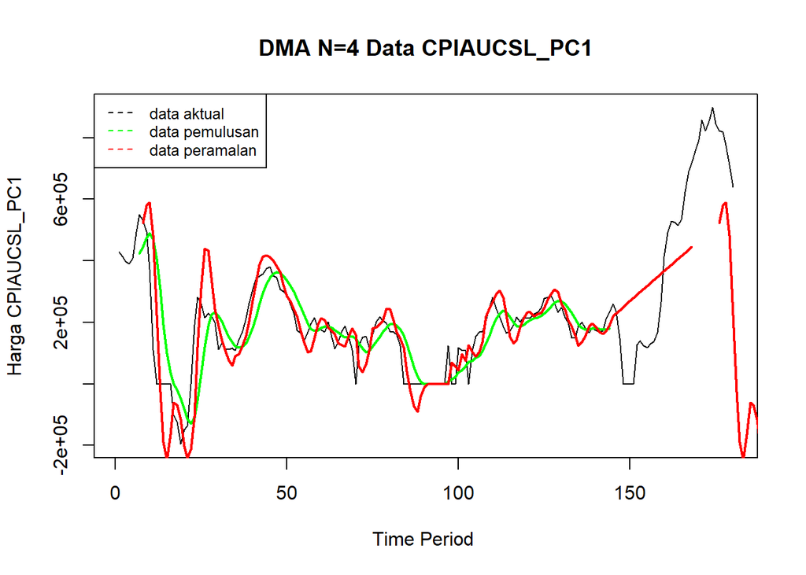

```r
ts.plot(data.ts, xlab="Time Period ", ylab="Harga CPIAUCSL_PC1", main= "DMA N=4 Data CPIAUCSL_PC1")
lines(data.gab2[,3],col="green",lwd=2)
lines(data.gab2[,6],col="red",lwd=2)
legend("topleft",c("data aktual","data pemulusan","data peramalan"), lty=8, col=c("black","green","red"), cex=0.8)
```

```r
#Menghitung nilai keakuratan data latih
error_train.dma = train_ma.ts-data.ramal2[1:length(train_ma.ts)]

SSE_train.dma = sum(error_train.dma[8:length(train_ma.ts)]^2)
MSE_train.dma = mean(error_train.dma[8:length(train_ma.ts)]^2)
MAPE_train.dma = mean(abs((error_train.dma[8:length(train_ma.ts)]/train_ma.ts[8:length(train_ma.ts)])*100))

akurasi_train.dma <- matrix(c(SSE_train.dma, MSE_train.dma, MAPE_train.dma))
row.names(akurasi_train.dma)<- c("SSE", "MSE", "MAPE")
colnames(akurasi_train.dma) <- c("Akurasi m = 4")
akurasi_train.dma
```

```
##      Akurasi m = 4
## SSE   942187280988
## MSE     6877279423
## MAPE      30026610
```

```r
#Menghitung nilai keakuratan data uji
error_test.dma = test_ma.ts-data.gab2[97:120,6]
```

```r
SSE_test.dma = sum(error_test.dma^2)
MSE_test.dma = mean(error_test.dma^2)
MAPE_test.dma = mean(abs((error_test.dma/test_ma.ts*100)))

akurasi_test.dma <- matrix(c(SSE_test.dma, MSE_test.dma, MAPE_test.dma))
row.names(akurasi_test.dma)<- c("SSE", "MSE", "MAPE")
colnames(akurasi_test.dma) <- c("Akurasi m = 4")
akurasi_test.dma
```

```
##      Akurasi m = 4
## SSE   7.539521e+12
## MSE   2.094311e+11
## MAPE  2.391346e+06
```

Nilai SSE dan MSE pada data uji lebih besar dibandingkan data latih. Hal ini menunjukkan bahwa kesalahan prediksi model pada data uji lebih tinggi, sehingga kemampuan model dalam melakukan generalisasi terhadap data yang belum pernah diamati masih kurang baik.

# Single Exponential Smoothing & Double Exponential Smoothing

## Pembagian Data

```r
data
```

```
## # A tibble: 180 × 2
##    observation_date    CPIAUCSL_PC1
##    <dttm>                     <dbl>
##  1 2008-01-01 00:00:00       429470
##  2 2008-02-01 00:00:00       414296
##  3 2008-03-01 00:00:00       397490
##  4 2008-04-01 00:00:00       390376
##  5 2008-05-01 00:00:00       408841
##  6 2008-06-01 00:00:00       493597
##  7 2008-07-01 00:00:00       549751
##  8 2008-08-01 00:00:00       530802
##  9 2008-09-01 00:00:00       495332
## 10 2008-10-01 00:00:00       373106
## # ℹ 170 more rows
```

```r
# jumlah baris data1
n <- nrow(data)

# hitung batas 80%
n_train <- floor(0.8 * n)

# bagi data
training <- data[1:n_train, ]
testing <- data[(n_train + 1):n, ]

# cek kolom
names(training)
```

```
## [1] "observation_date" "CPIAUCSL_PC1"
```

```r
names(testing)
```

```
## [1] "observation_date" "CPIAUCSL_PC1"
```

```r
# ubah ke time series
train.ts <- ts(training$CPIAUCSL_PC1)
test.ts <- ts(testing$CPIAUCSL_PC1)
```

## Eksplorasi

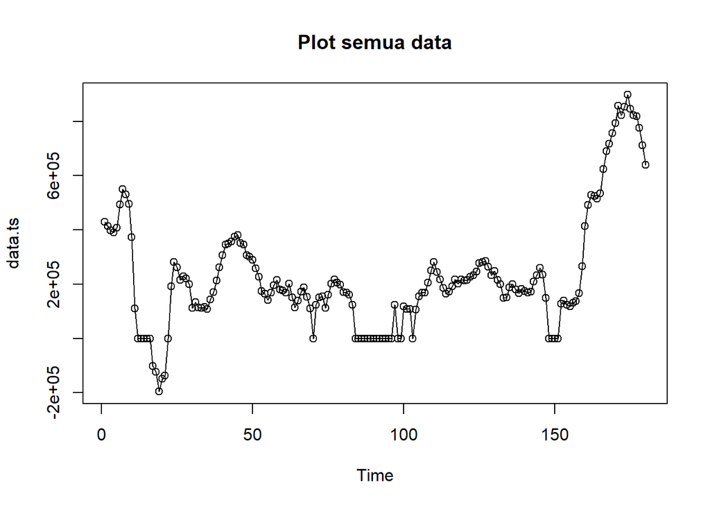

```r
#eksplorasi data
plot(data.ts, col="black",main="Plot semua data")
points(data.ts)
```

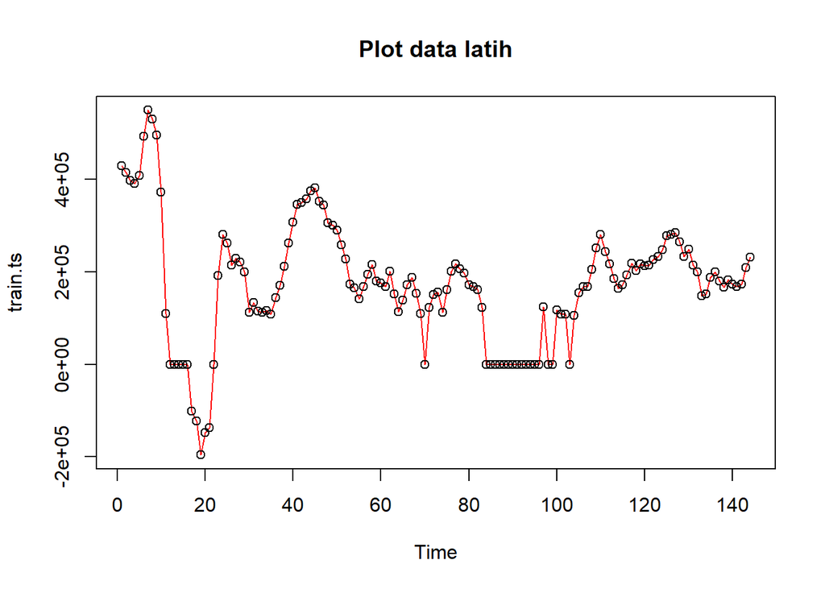

```r
plot(train.ts, col="red",main="Plot data latih")
points(train.ts)
```

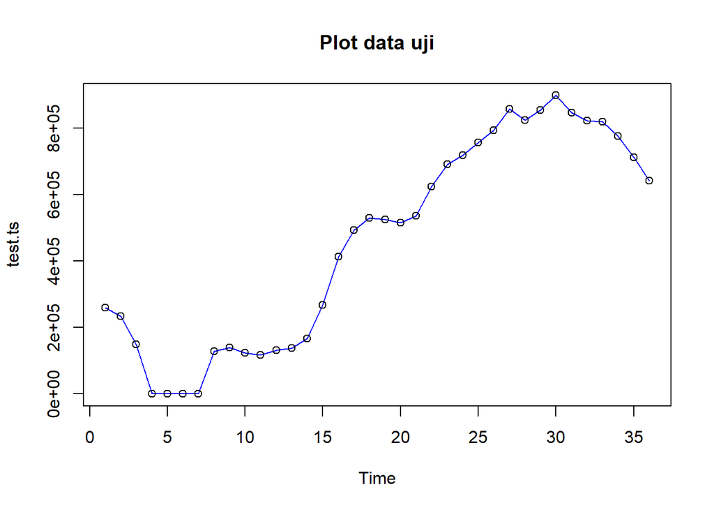

```r
plot(test.ts, col="blue",main="Plot data uji")
points(test.ts)
```

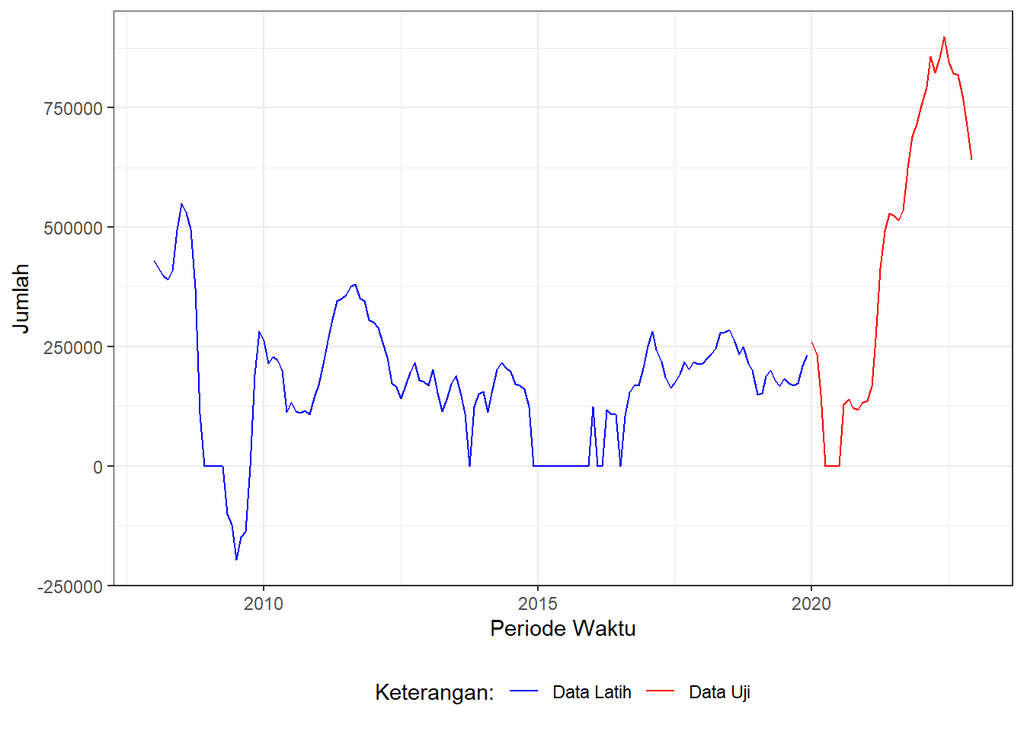

```r
# Eksplorasi dengan GGPLOT
library(ggplot2)

ggplot() +
  geom_line(
    data = training,
    aes(x = observation_date, y = CPIAUCSL_PC1, col = "Data Latih")
  ) +
  geom_line(
    data = testing,
    aes(x = observation_date, y = CPIAUCSL_PC1, col = "Data Uji")
  ) +
  labs(
    x = "Periode Waktu",
    y = "Jumlah",
    color = "Legend"
  ) +
  scale_colour_manual(
    name = "Keterangan:",
    breaks = c("Data Latih", "Data Uji"),
    values = c("blue", "red")
  ) +
  theme_bw() +
  theme(
    legend.position = "bottom",
    plot.caption = element_text(hjust = 0.5, size = 12)
  )
```

## Single Exponential Smoothing

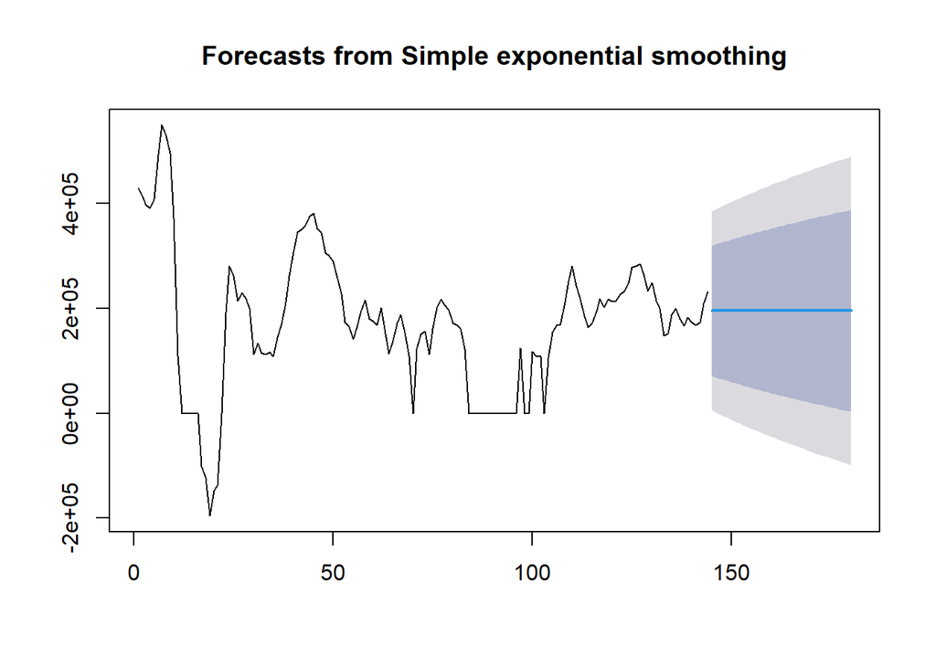

```r
#Cara 1 (fungsi ses)
library(forecast)
ses.1 <- ses(train.ts, h = nrow(testing), alpha = 0.2)
plot(ses.1)
```

```r
ses.1
```

```
##     Point Forecast     Lo 80    Hi 80      Lo 95    Hi 95
## 145       195470.4 71372.786 319568.1   5679.454 385261.4
## 146       195470.4 68915.168 322025.7   1920.852 389020.0
## 147       195470.4 66504.375 324436.5  -1766.138 392707.0
## 148       195470.4 64137.828 326803.1  -5385.460 396326.3
## 149       195470.4 61813.176 329127.7  -8940.708 399881.6
## 150       195470.4 59528.271 331412.6 -12435.169 403376.1
## 151       195470.4 57281.141 333659.7 -15871.858 406812.7
## 152       195470.4 55069.971 335870.9 -19253.549 410194.4
## 153       195470.4 52893.090 338047.8 -22582.802 413523.7
## 154       195470.4 50748.949 340191.9 -25861.982 416802.9
## 155       195470.4 48636.115 342304.8 -29093.284 420034.2
## 156       195470.4 46553.255 344387.6 -32278.744 423219.6
## 157       195470.4 44499.127 346441.8 -35420.260 426361.1
## 158       195470.4 42472.576 348468.3 -38519.603 429460.5
```

[output cut: 22 more lines]

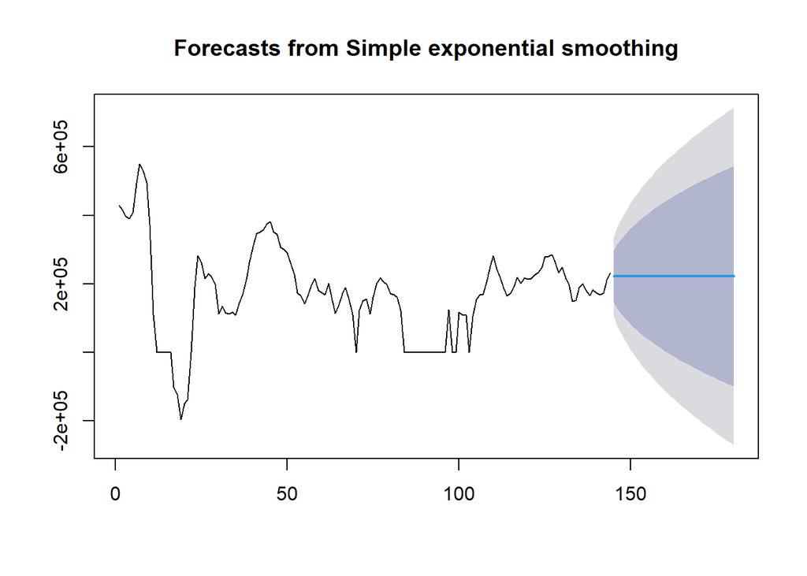

```r
ses.2<- ses(train.ts, nrow(testing), alpha = 0.7)
plot(ses.2)
```

```r
ses.2
```

```
##     Point Forecast      Lo 80    Hi 80       Lo 95    Hi 95
## 145       221834.3 146341.215 297327.4  106377.597 337291.0
## 146       221834.3 129683.249 313985.3   80901.436 362767.1
## 147       221834.3 115606.118 328062.5   59372.323 384296.2
## 148       221834.3 103187.611 340481.0   40379.855 403288.7
## 149       221834.3  91951.095 351717.5   23195.086 420473.5
## 150       221834.3  81612.129 362056.4    7383.003 436285.6
## 151       221834.3  71984.818 371683.8   -7340.699 451009.3
## 152       221834.3  62939.752 380728.8  -21173.934 464842.5
## 153       221834.3  54382.553 389286.0  -34261.040 477929.6
## 154       221834.3  46241.881 397426.7  -46711.124 490379.7
## 155       221834.3  38462.252 405206.3  -58609.039 502277.6
## 156       221834.3  30999.508 412669.1  -70022.322 513690.9
## 157       221834.3  23817.816 419850.8  -81005.772 524674.3
## 158       221834.3  16887.629 426780.9  -91604.578 535273.2
```

[output cut: 22 more lines]

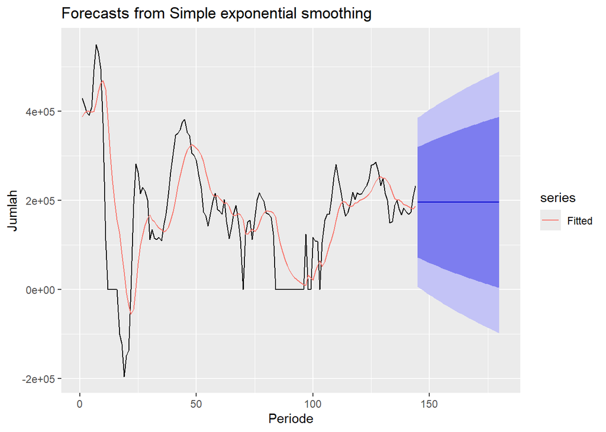

```r
autoplot(ses.1) +
  autolayer(fitted(ses.1), series="Fitted") +
  ylab("Jumlah") + xlab("Periode")
```

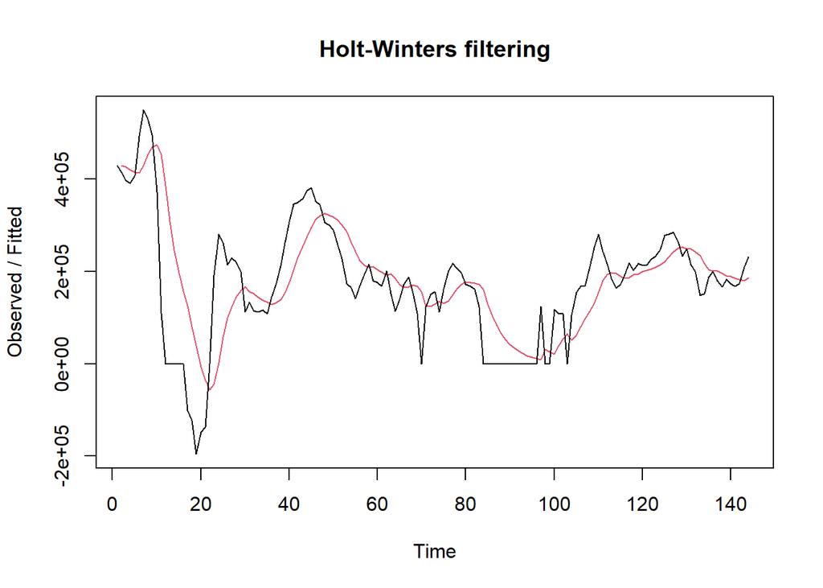

```r
#Cara 2 (fungsi Holtwinter)
ses1<- HoltWinters(train.ts, gamma = FALSE, beta = FALSE, alpha = 0.2)
plot(ses1)
```

```r
#ramalan
ramalan1<- forecast(ses1, h=10)
ramalan1
```

```
##     Point Forecast    Lo 80    Hi 80      Lo 95    Hi 95
## 145       195470.4 71596.07 319344.8   6020.944 384919.9
## 146       195470.4 69142.88 321798.0   2269.105 388671.8
## 147       195470.4 66736.42 324204.5  -1411.252 392352.1
## 148       195470.4 64374.13 326566.8  -5024.061 395965.0
## 149       195470.4 62053.66 328887.2  -8572.912 399513.8
## 150       195470.4 59772.87 331168.0 -12061.085 403002.0
## 151       195470.4 57529.78 333411.1 -15491.591 406432.5
## 152       195470.4 55322.59 335618.3 -18867.198 409808.1
## 153       195470.4 53149.63 337791.3 -22190.460 413131.3
## 154       195470.4 51009.35 339931.5 -25463.740 416404.6
```

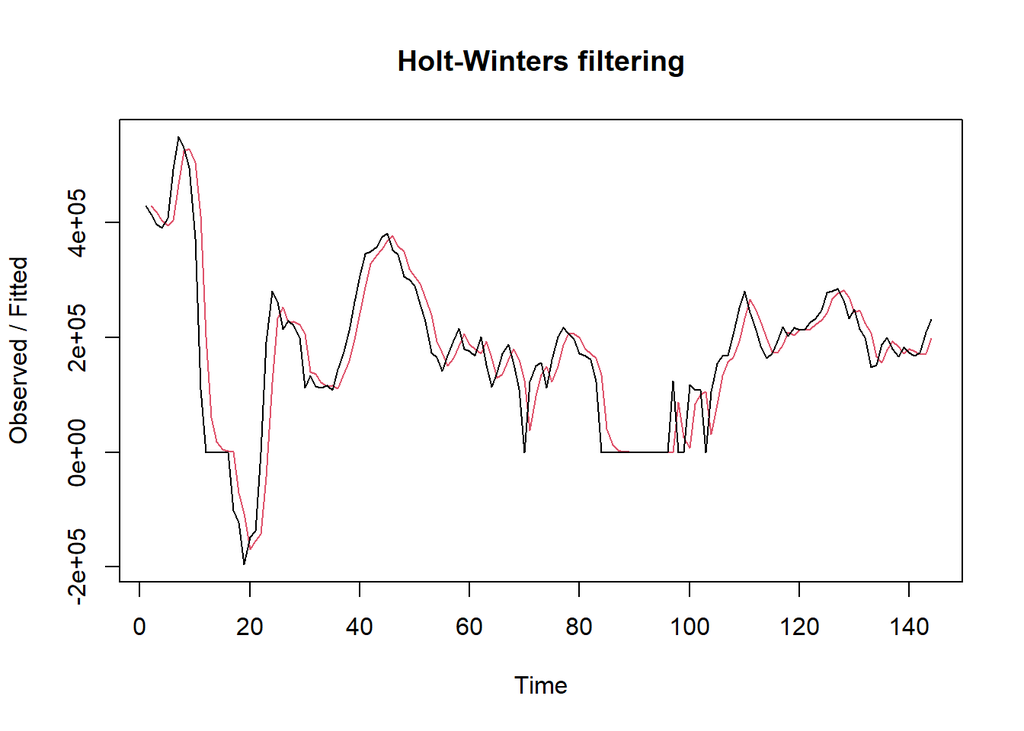

```r
ses2<- HoltWinters(train.ts, gamma = FALSE, beta = FALSE, alpha = 0.7)
plot(ses2)
```

```r
#ramalan
ramalan2<- forecast(ses2, h=10)
ramalan2
```

```
##     Point Forecast     Lo 80    Hi 80      Lo 95    Hi 95
## 145       221834.3 146385.46 297283.1 106445.262 337223.3
## 146       221834.3 129737.25 313931.3  80984.032 362684.5
## 147       221834.3 115668.37 328000.2  59467.536 384201.0
## 148       221834.3 103257.15 340411.4  40486.199 403182.4
## 149       221834.3  92027.21 351641.4  23311.502 420357.1
## 150       221834.3  81694.31 361974.3   7508.685 436159.9
## 151       221834.3  72072.64 371595.9  -7206.388 450875.0
## 152       221834.3  63032.87 380635.7 -21031.516 464700.1
## 153       221834.3  54480.69 389187.9 -34110.952 477779.5
## 154       221834.3  46344.79 397323.8 -46553.739 490222.3
```

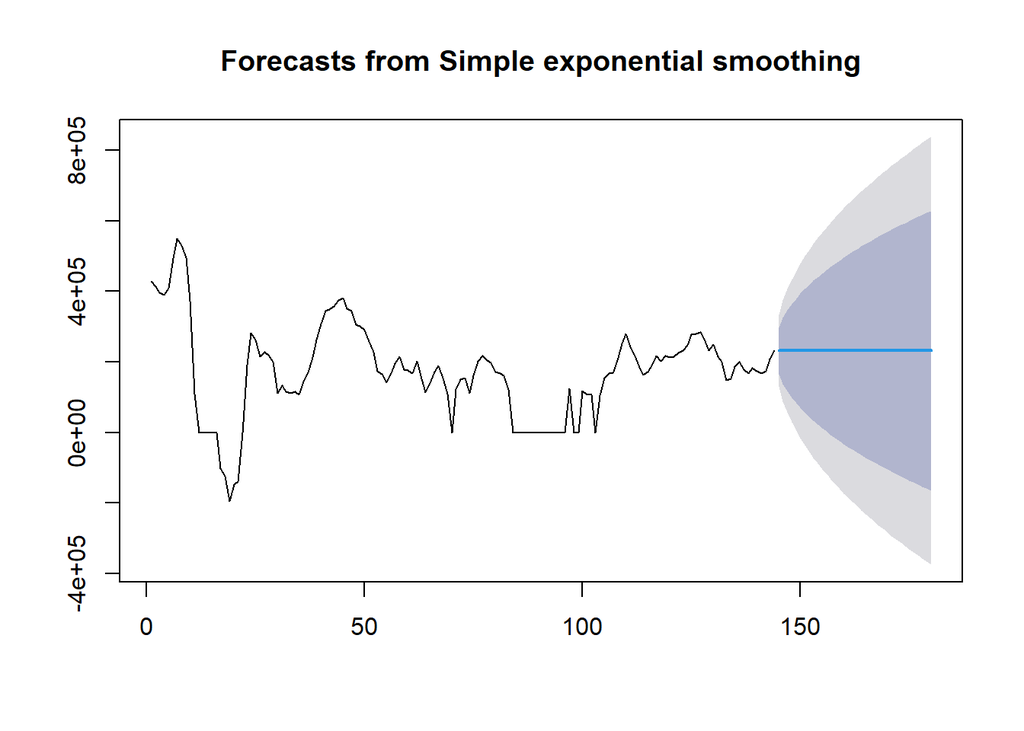

```r
#SES
ses.opt <- ses(train.ts, nrow(testing), alpha = NULL)
plot(ses.opt)
```

```r
ses.opt
```

```
##     Point Forecast       Lo 80    Hi 80       Lo 95    Hi 95
## 145       231950.7  165861.211 298040.2  130875.534 333025.9
## 146       231950.7  138490.710 325410.7   89015.966 374885.5
## 147       231950.7  117487.959 346413.5   56895.029 407006.4
## 148       231950.7   99781.608 364119.8   29815.503 434086.0
## 149       231950.7   84181.899 379719.6    5957.807 457943.6
## 150       231950.7   70078.626 393822.8  -15611.288 479512.7
## 151       231950.7   57109.291 406792.2  -35446.174 499347.6
## 152       231950.7   45037.704 418863.8  -53908.074 517809.5
## 153       231950.7   33699.803 430201.7  -71247.897 535149.4
## 154       231950.7   22976.137 440925.3  -87648.329 551549.8
## 155       231950.7   12776.527 451124.9 -103247.286 567148.7
## 156       231950.7    3030.915 460870.5 -118151.914 582053.4
## 157       231950.7   -6316.415 470217.9 -132447.422 596348.9
## 158       231950.7  -15310.636 479212.1 -146202.895 610104.3
```

[output cut: 22 more lines]

```r
#Lamda Optimum Holt Winter
HWopt<- HoltWinters(train.ts, gamma = FALSE, beta = FALSE,alpha = NULL)
HWopt
```

```
## Holt-Winters exponential smoothing without trend and without seasonal component.
##
## Call:
## HoltWinters(x = train.ts, alpha = NULL, beta = FALSE, gamma = FALSE)
##
## Smoothing parameters:
##  alpha: 0.9999243
##  beta : FALSE
##  gamma: FALSE
##
## Coefficients:
##       [,1]
## a 231951.3
```

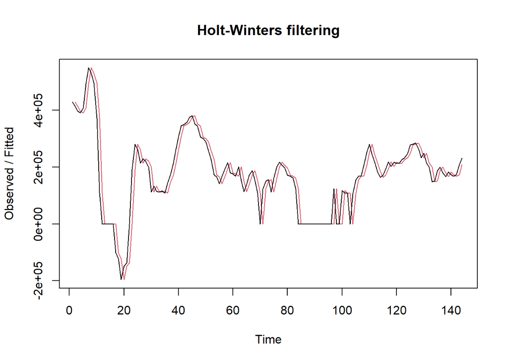

```r
plot(HWopt)
```

```r
#ramalan
ramalanopt<- forecast(HWopt, h=10)
ramalanopt
```

```
##     Point Forecast     Lo 80    Hi 80      Lo 95    Hi 95
## 145       231951.3 165917.19 297985.4 130960.854 332941.7
## 146       231951.3 138568.51 325334.1  89134.652 374767.9
## 147       231951.3 117582.65 346319.9  57039.552 406863.0
## 148       231951.3  99890.59 364012.0  29981.887 433920.7
## 149       231951.3  84303.50 379599.1   6143.488 457759.1
## 150       231951.3  70211.65 393690.9 -15408.139 479310.7
## 151       231951.3  57252.83 406649.7 -35226.947 499129.5
## 152       231951.3  45191.03 418711.5 -53673.874 517576.4
## 153       231951.3  33862.33 430040.2 -70999.626 534902.2
## 154       231951.3  23147.37 440755.2 -87386.746 551289.3
```

## Akurasi Data Latih

```r
#Keakuratan Metode
#Pada data training

# SES dengan alpha = 0.2
SSE1<-ses1$SSE
MSE1<-ses1$SSE/length(train.ts)
RMSE1<-sqrt(MSE1)

akurasi1 <- matrix(c(SSE1,MSE1,RMSE1))
row.names(akurasi1)<- c("SSE", "MSE", "RMSE")
colnames(akurasi1) <- c("Akurasi lamda=0.2")
akurasi1
```

```
##      Akurasi lamda=0.2
## SSE       1.336292e+12
## MSE       9.279806e+09
## RMSE      9.633175e+04
```

```r
# SES dengan alpha = 0.7
SSE2<-ses2$SSE
MSE2<-ses2$SSE/length(train.ts)
RMSE2<-sqrt(MSE2)

akurasi2 <- matrix(c(SSE2,MSE2,RMSE2))
row.names(akurasi2)<- c("SSE", "MSE", "RMSE")
colnames(akurasi2) <- c("Akurasi lamda=0.7")
akurasi2
```

```
##      Akurasi lamda=0.7
## SSE       4.927921e+11
## MSE       3.422167e+09
## RMSE      5.849929e+04
```

```r
SSE1<-ses1$SSE
SSE1
```

```
## [1] 1.336292e+12
```

```r
#Cara Manual
# Alpha = 0.2
fitted1<-ramalan1$fitted
sisaan1<-ramalan1$residuals
head(sisaan1)
```

```
## Time Series:
## Start = 1
## End = 6
## Frequency = 1
## [1]         NA -15174.000 -28945.200 -30270.160  -5751.128  80155.098
```

```r
resid1<-training$CPIAUCSL_PC1-ramalan1$fitted
head(resid1)
```

```
## Time Series:
## Start = 1
## End = 6
## Frequency = 1
## [1]         NA -15174.000 -28945.200 -30270.160  -5751.128  80155.098
```

```r
SSE.1=sum(sisaan1[2:length(train.ts)]^2)
SSE.1
```

```
## [1] 1.336292e+12
```

```r
MSE.1 = SSE.1/length(train.ts)
MSE.1
```

```
## [1] 9279806437
```

```r
MAPE.1 = sum(abs(sisaan1[2:length(train.ts)]/train.ts[2:length(train.ts)])*
               100)/length(train.ts)
MAPE.1
```

```
## [1] 42726030
```

```r
akurasi.1 <- matrix(c(SSE.1,MSE.1,MAPE.1))
row.names(akurasi.1)<- c("SSE", "MSE", "MAPE")
colnames(akurasi.1) <- c("Akurasi lamda=0.2")
akurasi.1
```

```
##      Akurasi lamda=0.2
## SSE       1.336292e+12
## MSE       9.279806e+09
## MAPE      4.272603e+07
```

```r
# Alpha = 0.7
fitted2<-ramalan2$fitted
sisaan2<-ramalan2$residuals
head(sisaan2)
```

```
## Time Series:
## Start = 1
## End = 6
## Frequency = 1
## [1]        NA -15174.00 -21358.20 -13521.46  14408.56  89078.57
```

```r
resid2<-training$CPIAUCSL_PC1-ramalan2$fitted
head(resid2)
```

```
## Time Series:
## Start = 1
## End = 6
## Frequency = 1
## [1]        NA -15174.00 -21358.20 -13521.46  14408.56  89078.57
```

```r
SSE.2=sum(sisaan2[2:length(train.ts)]^2)
SSE.2
```

```
## [1] 492792112679
```

```r
MSE.2 = SSE.2/length(train.ts)
MSE.2
```

```
## [1] 3422167449
```

```r
MAPE.2 = sum(abs(sisaan2[2:length(train.ts)]/train.ts[2:length(train.ts)])*
               100)/length(train.ts)
MAPE.2
```

```
## [1] 9348318
```

```r
akurasi.2 <- matrix(c(SSE.2,MSE.2,MAPE.2))
row.names(akurasi.2)<- c("SSE", "MSE", "MAPE")
colnames(akurasi.2) <- c("Akurasi lamda=0.7")
akurasi.2
```

```
##      Akurasi lamda=0.7
## SSE       492792112679
## MSE         3422167449
## MAPE           9348318
```

## Akurasi Data Uji

```r
# jumlah observasi uji
n_test <- nrow(testing)

# error (ramalan - aktual), samakan panjang dan tipe numeric
e1   <- as.numeric(ramalan1$mean)[1:n_test] - as.numeric(testing$CPIAUCSL_PC1)
e2   <- as.numeric(ramalan2$mean)[1:n_test] - as.numeric(testing$CPIAUCSL_PC1)
eopt <- as.numeric(ramalanopt$mean)[1:n_test] - as.numeric(testing$CPIAUCSL_PC1)

# SSE / MSE / RMSE untuk masing-masing model (abaikan NA)
SSEtesting1  <- sum(e1^2,  na.rm = TRUE)
MSEtesting1  <- mean(e1^2, na.rm = TRUE)
RMSEtesting1 <- sqrt(MSEtesting1)

SSEtesting2  <- sum(e2^2,  na.rm = TRUE)
MSEtesting2  <- mean(e2^2, na.rm = TRUE)
RMSEtesting2 <- sqrt(MSEtesting2)

SSEtestingopt  <- sum(eopt^2,  na.rm = TRUE)
MSEtestingopt  <- mean(eopt^2, na.rm = TRUE)
RMSEtestingopt <- sqrt(MSEtestingopt)

# Tabel ringkas
akurasitesting_SSE <- matrix(c(SSEtesting1, SSEtesting2, SSEtestingopt),
                             nrow = 3,
                             dimnames = list(c("SSE1","SSE2","SSEopt"), "Nilai"))
akurasitesting_MSE <- matrix(c(MSEtesting1, MSEtesting2, MSEtestingopt),
                             nrow = 3,
                             dimnames = list(c("MSE1","MSE2","MSEopt"), "Nilai"))
akurasitesting_RMSE <- matrix(c(RMSEtesting1, RMSEtesting2, RMSEtestingopt),
                              nrow = 3,
                              dimnames = list(c("RMSE1","RMSE2","RMSEopt"), "Nilai"))

akurasitesting_SSE
```

```
##               Nilai
## SSE1   173573387251
## SSE2   229083006093
## SSEopt 254075312753
```

```r
akurasitesting_MSE
```

```
##              Nilai
## MSE1   17357338725
## MSE2   22908300609
## MSEopt 25407531275
```

```r
akurasitesting_RMSE
```

```
##            Nilai
## RMSE1   131747.3
## RMSE2   151354.9
## RMSEopt 159397.4
```

## Double Exponential Smoothing (DES)

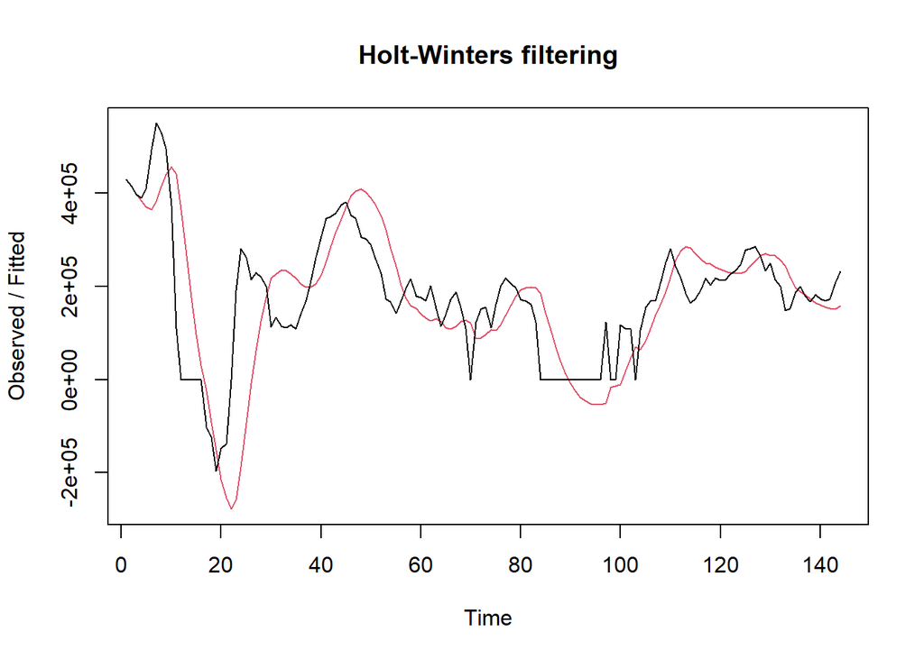

```r
#Lamda=0.2 dan gamma=0.2
des.1<- HoltWinters(train.ts, gamma = FALSE, beta = 0.2, alpha = 0.2)
plot(des.1)
```

```r
#ramalan
ramalandes1<- holt(
  train.ts,
  h = nrow(testing)
)
ramalandes1
```

```
##     Point Forecast       Lo 80    Hi 80      Lo 95     Hi 95
## 145       233997.9  166737.709 301258.1  131132.32  336863.4
## 146       236044.8  140510.142 331579.6   89937.12  382152.6
## 147       238091.8  120573.933 355609.7   58363.72  417819.9
## 148       240138.8  103847.373 376430.2   31699.06  448578.5
## 149       242185.8   89142.398 395229.1    8126.14  476245.4
## 150       244232.7   75852.464 412613.0  -13282.66  501748.1
## 151       246279.7   63618.865 428940.5  -33075.94  525635.3
## 152       248326.7   52208.923 444444.4  -51609.53  548262.8
## 153       250373.6   41461.735 459285.5  -69129.54  569876.8
## 154       252420.6   31260.667 473580.5  -85814.33  590655.5
## 155       254467.6   21518.058 487417.1 -101797.96  610733.1
## 156       256514.5   12166.105 500863.0 -117184.14  630213.2
## 157       258561.5    3151.128 513971.9 -132054.95  649177.9
## 158       260608.5   -5570.204 526787.1 -146476.68  667693.6
```

[output cut: 22 more lines]

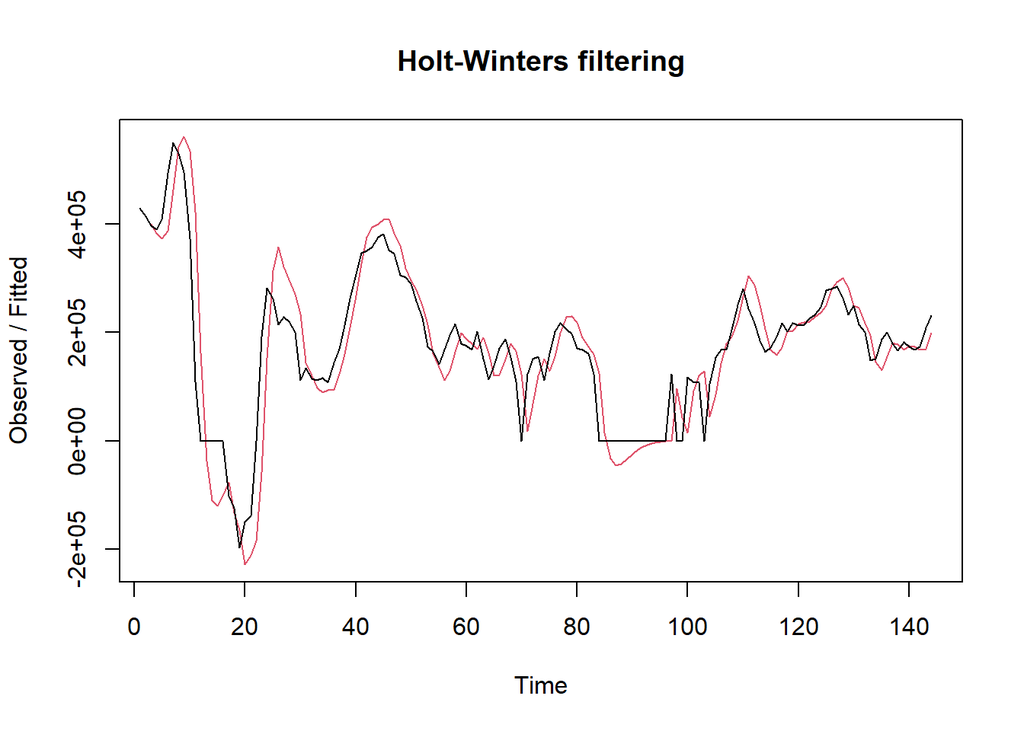

```r
#Lamda=0.6 dan gamma=0.3
des.2<- HoltWinters(train.ts, gamma = FALSE, beta = 0.3, alpha = 0.6)
plot(des.2)
```

```r
#ramalan
ramalandes2<- forecast(des.2, h=10)
ramalandes2
```

```
##     Point Forecast      Lo 80    Hi 80      Lo 95    Hi 95
## 145       230555.4 146054.959 315055.9  101323.11 359787.8
## 146       242209.5 135043.722 349375.3   78313.57 406105.5
## 147       253863.6 119457.363 388269.8   48307.00 459420.2
## 148       265517.7 100155.624 430879.8   12618.23 518417.1
## 149       277171.8  77707.675 476635.9  -27882.24 582225.8
## 150       288825.9  52496.273 525155.4  -72609.05 650260.8
## 151       300479.9  24790.725 576169.1 -121150.33 722110.2
## 152       312134.0  -5210.007 629478.0 -173201.79 797469.8
## 153       323788.1 -37352.359 684928.6 -228528.57 876104.8
## 154       335442.2 -71513.391 742397.8 -286942.66 957827.0
```

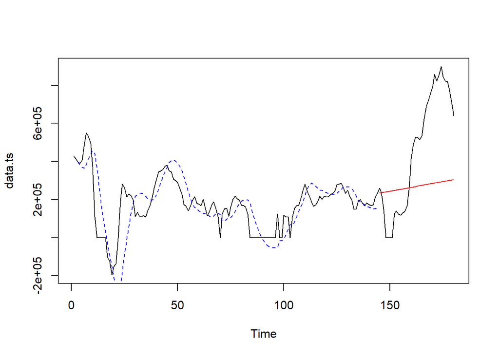

```r
plot(data.ts)
lines(des.1$fitted[,1], lty=2, col="blue")
lines(ramalandes1$mean, col="red")
```

```r
#Lamda dan gamma optimum
des.opt<- HoltWinters(train.ts, gamma = FALSE)
des.opt
```

```
## Holt-Winters exponential smoothing with trend and without seasonal component.
##
## Call:
## HoltWinters(x = train.ts, gamma = FALSE)
##
## Smoothing parameters:
##  alpha: 1
##  beta : 0.02055708
##  gamma: FALSE
##
## Coefficients:
##          [,1]
## a 231953.0000
## b    179.8231
```

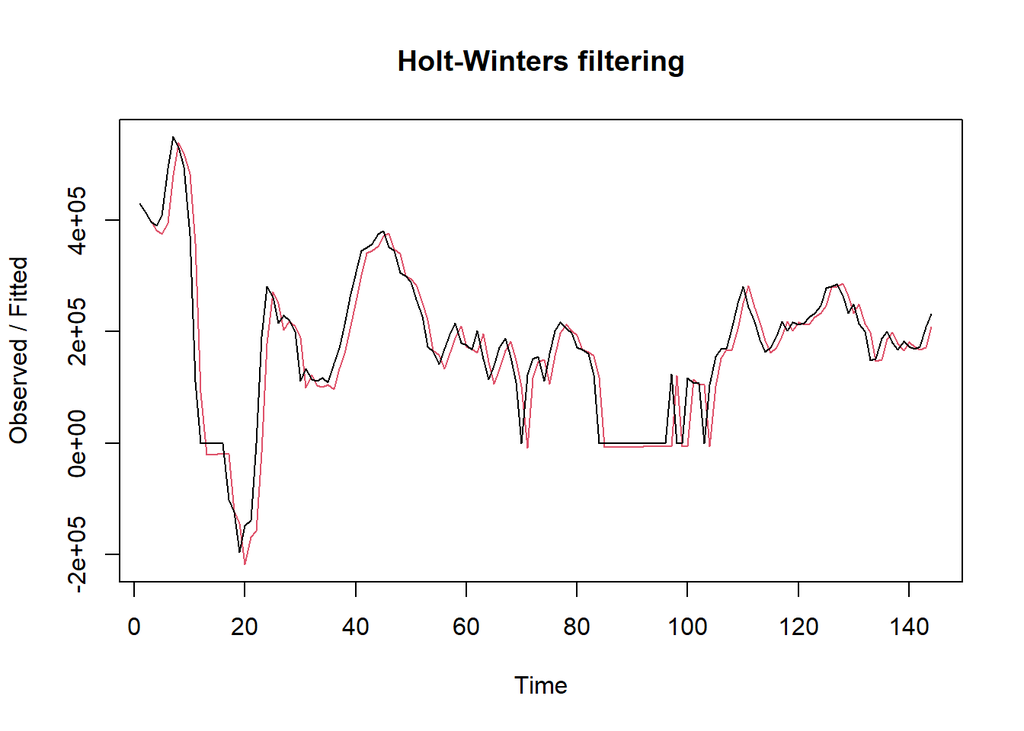

```r
plot(des.opt)
```

```r
#ramalan
ramalandesopt<- forecast(des.opt, h=10)
ramalandesopt
```

```
##     Point Forecast      Lo 80    Hi 80       Lo 95    Hi 95
## 145       232132.8 165462.701 298802.9  130169.671 334096.0
## 146       232312.6 137052.806 327572.5   86625.292 378000.0
## 147       232492.5 114626.643 350358.3   52232.243 412752.7
## 148       232672.3  95186.259 370158.3   22405.549 442939.0
## 149       232852.1  77583.435 388120.8   -4610.839 470315.1
## 150       233031.9  61235.633 404828.2  -29707.838 495771.7
## 151       233211.8  45800.478 420623.0  -53409.063 519832.6
## 152       233391.6  31057.269 435725.9  -76052.048 542835.2
## 153       233571.4  16854.344 450288.5  -97868.740 565011.6
## 154       233751.2   3082.469 464420.0 -119026.197 586528.7
```

```r
#Akurasi Data Training
ssedes.train1<-des.1$SSE
msedes.train1<-ssedes.train1/length(train.ts)
sisaandes1<-ramalandes1$residuals
head(sisaandes1)
```

```
## Time Series:
## Start = 1
## End = 6
## Frequency = 1
## [1] -24200.95 -22778.35 -24209.86 -14305.07  11400.75  77594.04
```

```r
mapedes.train1 <- sum(abs(sisaandes1[3:length(train.ts)]/train.ts[3:length(train.ts)])
                      *100)/length(train.ts)

akurasides.1 <- matrix(c(ssedes.train1,msedes.train1,mapedes.train1))
row.names(akurasides.1)<- c("SSE", "MSE", "MAPE")
colnames(akurasides.1) <- c("Akurasi lamda=0.2 dan gamma=0.2")
akurasides.1
```

```
##      Akurasi lamda=0.2 dan gamma=0.2
## SSE                     1.705203e+12
## MSE                     1.184169e+10
## MAPE                    4.835834e+06
```

```r
ssedes.train2<-des.2$SSE
msedes.train2<-ssedes.train2/length(train.ts)
sisaandes2<-ramalandes2$residuals
head(sisaandes2)
```

```
## Time Series:
## Start = 1
## End = 6
## Frequency = 1
## [1]        NA        NA  -1632.00   7700.96  35626.97 106675.52
```

```r
mapedes.train2 <- sum(abs(sisaandes2[3:length(train.ts)]/train.ts[3:length(train.ts)])
                      *100)/length(train.ts)

akurasides.2 <- matrix(c(ssedes.train2,msedes.train2,mapedes.train2))
row.names(akurasides.2)<- c("SSE", "MSE", "MAPE")
colnames(akurasides.2) <- c("Akurasi lamda=0.6 dan gamma=0.3")
akurasides.2
```

```
##      Akurasi lamda=0.6 dan gamma=0.3
## SSE                     613163241200
## MSE                       4258078064
## MAPE                        18865271
```

```r
length(ramalandes1$mean)
```

```
## [1] 36
```

```r
length(testing$CPIAUCSL_PC1)
```

```
## [1] 36
```

## Akurasi Data Uji

```r
selisihdes1 <- ramalandes1$mean - testing$CPIAUCSL_PC1

selisihdes1
```

```
## Time Series:
## Start = 145
## End = 180
## Frequency = 1
##  [1]  -25979.119    1912.849   88687.817  240138.472  242185.555  244232.004
##  [7]  246278.692  120219.657  111271.625  129381.593  136892.561  124472.529
## [13]  121177.497   93626.465   -4126.567 -148605.599 -225076.632 -260766.664
## [19] -253673.696 -242311.728 -260184.760 -346519.792 -411165.824 -436355.856
## [25] -472755.888 -508555.920 -570000.952 -533908.984 -562504.016 -604576.048
## [31] -550851.080 -524804.112 -519710.145 -474333.177 -408691.209 -334818.241
```

```r
MAE <- mean(abs(selisihdes1))
MSE <- mean(selisihdes1^2)
RMSE <- sqrt(MSE)

MAE
```

```
## [1] 293909.8
```

```r
MSE
```

```
## [1] 119015911352
```

```r
RMSE
```

```
## [1] 344986.8
```

```r
# Data aktual
aktual <- as.numeric(testing$CPIAUCSL_PC1)

# Forecast DES
forecast_des1   <- as.numeric(ramalandes1$mean)
forecast_des2   <- as.numeric(ramalandes2$mean)
forecast_desopt <- as.numeric(ramalandesopt$mean)

# Error
e_des1   <- forecast_des1 - aktual
e_des2   <- forecast_des2 - aktual
e_desopt <- forecast_desopt - aktual
# MSE
MSEtestingdes1   <- mean(e_des1^2)
MSEtestingdes2   <- mean(e_des2^2)
MSEtestingdesopt <- mean(e_desopt^2)

# RMSE
RMSEtestingdes1   <- sqrt(MSEtestingdes1)
RMSEtestingdes2   <- sqrt(MSEtestingdes2)
RMSEtestingdesopt <- sqrt(MSEtestingdesopt)
```

```r
MSEfull <- matrix(
  c(MSEtesting1, MSEtesting2, MSEtestingopt,
    MSEtestingdes1, MSEtestingdes2, MSEtestingdesopt),
  nrow = 3,
  ncol = 2
)

rownames(MSEfull) <- c("ske 1", "ske 2", "ske opt")
colnames(MSEfull) <- c("SES", "DES")

MSEfull
```

```
##                 SES          DES
## ske 1   17357338725 119015911352
## ske 2   22908300609 126670774116
## ske opt 25407531275 145731622315
```

# Pemulusan Data Musiman

```r
# bagi data
training.w <- data[1:n_train, ]
testing.w <- data[(n_train+1):n, ]

# ubah ke time series
train_ma.w <- ts(
  training.w$CPIAUCSL_PC1,
  frequency = 12
)

test_ma.w <- ts(
  testing.w$CPIAUCSL_PC1,
  frequency = 12
)

# cek
frequency(train_ma.w)
```

```
## [1] 12
```

## Winter Aditif

```r
# Pemulusan dengan Winter aditif
winter1 <- HoltWinters(
  train_ma.w,
  alpha = 0.2,
  beta = 0.1,
  gamma = 0.1,
  seasonal = "additive"
)

winter1$fitted
```

```
##               xhat        level         trend       season
## Jan  2  243306.747  414678.9447 -41516.090509 -129856.1071
## Feb  2  207630.478  324501.4821 -46382.227723  -70488.7767
## Mar  2  170248.758  236593.1605 -50534.837107  -15809.5650
## Apr  2  124185.309  152008.4825 -53939.821205   26116.6478
## May  2  -46499.196   73231.4842 -56423.538912  -63307.1415
## Jun  2 -151500.591    5792.5845 -57525.074987  -99768.1008
## Jul  2   73872.283  -46015.7722 -56953.403161  176841.4589
## Aug  2  -26217.821 -156918.8321 -62348.368831  193049.3799
## Sep  2 -117088.314 -243700.4367 -64791.692411  191403.8148
## Oct  2 -275833.465 -312633.2663 -65205.806126  102005.6074
## Nov  2 -505936.892 -322672.4242 -59689.141306 -123575.3269
## Dec  2 -475235.501 -242882.3870 -45741.223459 -186611.8908
## Jan  3 -317223.040 -137294.1102 -30608.273434 -149320.6560
## Feb  3 -158156.383  -52035.5757 -19021.592641  -87099.2143
## Mar  3  -37384.378    3600.9082 -11555.784988  -29429.5014
## Apr  3   55191.418   45245.3988  -6235.757423   16181.7770
## May  3    1467.426   72106.7577  -2926.045790  -67713.2858
## Jun  3   12528.519  108958.2267   1051.705688  -97481.4135
## Jul  3  288241.280  129935.4286   3044.255310  155261.5962
## Aug  3  285384.103  102147.0279    -39.010292  183276.0856
## Sep  3  254335.825   68034.7970  -3446.332356  189747.3600
## Oct  3  153863.338   36087.4997  -6296.428848  124072.2667
## Nov  3  -52471.548   22352.4033  -7040.295600  -67783.6555
## Dec  3  -82404.658   47497.2173  -3821.784645 -126080.0907
## Jan  4  -13359.880   88912.1642    701.888516 -102973.9328
## Feb  4   73436.291  126301.6288   4370.646117  -57235.9837
## Mar  4  157485.346  158483.0166   7151.720292   -8149.3912
## Apr  4  225183.585  186522.4678   9240.493377   29420.6235
## May  4  171359.846  212270.8442  10891.281683  -51802.2799
## Jun  4  182940.366  258069.5567  14382.024764  -89511.2150
## Jul  4  466566.299  305909.9082  17727.857435  142928.5338
## Aug  4  487125.195  301922.1057  15556.291447  169646.7973
## Sep  4  486824.120  295153.3583  13323.787556  178346.9740
## Oct  4  419674.067  287364.7219  11212.545159  121096.7997
## Nov  4  240041.846  285087.8537   9863.603824  -54909.6117
## Dec  4  219951.917  315971.6883  11965.626908 -107985.3980
## Jan  5  270580.158  345188.3318  13690.728563  -88298.9024
## Feb  5  333123.407  364938.4288  14296.665404  -46111.6870
## Mar  5  384210.271  370574.0127  13430.557260     205.7012
```

[output cut: 78 more lines]

```
## Oct 11  326223.103  236026.1057   2288.238063   87908.7593
## Nov 11  223782.720  222910.3231    747.836001     124.5614
## Dec 11  179543.209  221848.2150    566.841591  -42871.8471
## Jan 12  196800.989  226554.0147    980.737402  -30733.7632
## Feb 12  193825.778  217926.3543     19.897622  -24120.4738
## Mar 12  201692.286  209558.2963   -818.897941   -7047.1129
## Apr 12  223162.244  206064.7413  -1086.363652   18183.8661
## May 12  175998.709  200357.5289  -1548.448527  -22810.3709
## Jun 12  149023.601  199527.5385  -1476.602715  -49027.3349
## Jul 12  255561.834  201670.0156  -1114.694733   55006.5134
## Aug 12  269462.730  185969.5540  -2573.271417   86066.4470
## Sep 12  264307.361  164256.5367  -4487.246008  104538.0699
## Oct 12  215940.576  140597.8186  -6404.393219   81747.1511
## Nov 12  117830.029  125684.7101  -7255.264748    -599.4163
## Dec 12   90065.690  136709.2395  -5427.285328  -41216.2639
```

```r
# Nilai fitted dari Winter Additif
xhat1 <- winter1$fitted[,1]

# Winter Additif dengan parameter optimal
winter1.opt <- HoltWinters(
  train_ma.w,
  alpha = NULL,
  beta = NULL,
  gamma = NULL,
  seasonal = "additive"
)

winter1.opt
```

```
## Holt-Winters exponential smoothing with trend and additive seasonal component.
##
## Call:
## HoltWinters(x = train_ma.w, alpha = NULL, beta = NULL, gamma = NULL,     seasonal = "additive")
##
## Smoothing parameters:
##  alpha: 0.7473847
##  beta : 0.02328373
##  gamma: 1
##
## Coefficients:
##             [,1]
## a    90001.16585
## b    -3033.35686
## s1   96755.96316
## s2   43779.35731
## s3      79.70315
## s4   -9973.73096
## s5  -14617.54266
## s6  -17447.87724
## s7  -13527.85379
## s8   13175.98978
## s9   61350.56622
## s10 111800.32128
## s11 145309.12838
## s12 141951.83415
```

## Peramalan

```r
#Forecast
forecast1 <- predict(winter1, n.ahead = 49)
forecast1.opt <- predict(winter1.opt, n.ahead = 49)
```

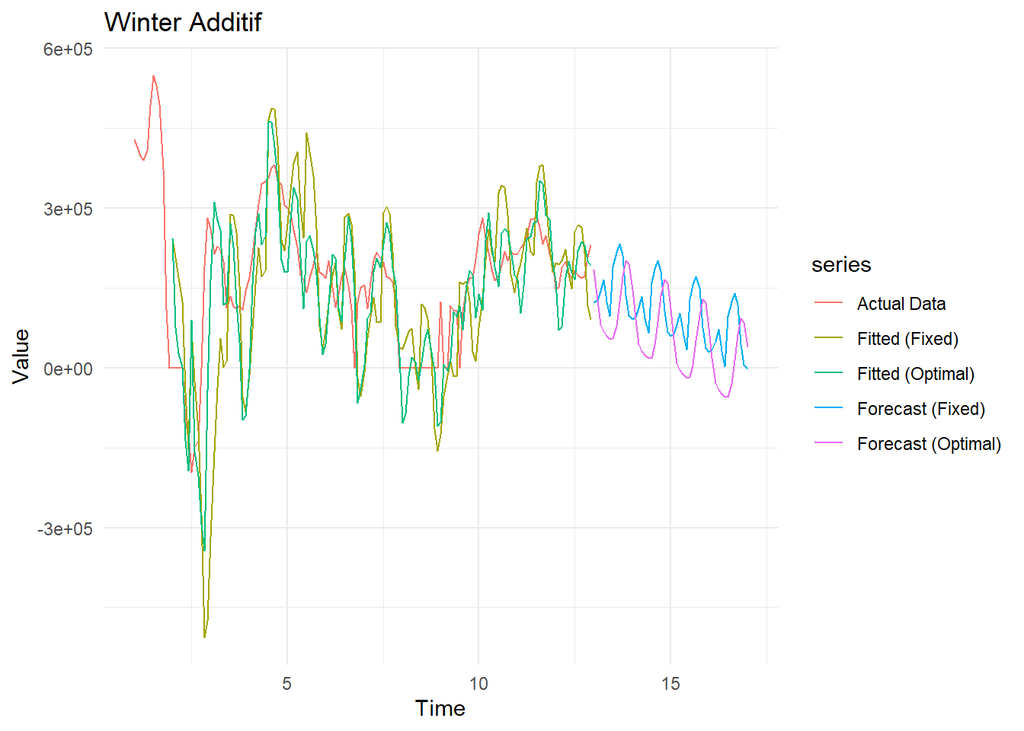

```r
library(forecast)
library(ggplot2)

# Mengambil fitted values langsung dari objek model Holt-Winters
fitted_fixed <- fitted(winter1)[, "xhat"]
fitted_opt   <- fitted(winter1.opt)[, "xhat"]

# Plot dengan autoplot
autoplot(train_ma.w, series = "Actual Data") +
  autolayer(fitted_fixed, series = "Fitted (Fixed)") +
  autolayer(fitted_opt, series = "Fitted (Optimal)") +
  autolayer(forecast1, series = "Forecast (Fixed)", PI = FALSE) +
  autolayer(forecast1.opt, series = "Forecast (Optimal)", PI = FALSE) +
  labs(title = "Winter Additif", x = "Time", y = "Value") +
  theme_minimal()
```